# Problem 2: Logistic Regression and LDA

## Problem Statement:

##### You are hired by a tour and travel agency which deals in selling holiday packages. You are provided details of 872 employees of a company. Among these employees, some opted for the package and some didn't. You have to help the company in predicting whether an employee will opt for the package or not based on the information given in the data set. Also, find out the important factors based on which the company will focus on particular employees to sell their packages.

## Data Dictionary:

Variable Name-Description

Holiday_Package-Opted for Holiday Package yes/no?

Salary- Employee salary

age -Age in years

edu- Years of formal education

no_young_children -The number of young children (younger than 7 years)

no_older_children- Number of older children

foreign- foreigner Yes/No

## Importing required packages:

```python
import numpy as np
import pandas as pd
import matplotlib.pyplot as plt
import seaborn as sns
from sklearn.model_selection import train_test_split,GridSearchCV
from sklearn.linear_model import LogisticRegression
from sklearn import metrics
from sklearn.metrics import roc_auc_score,roc_curve,classification_report,confusion_matrix,plot_confusion_matrix
from sklearn.discriminant_analysis import LinearDiscriminantAnalysis
from sklearn import metrics,model_selection
from sklearn.preprocessing import scale
from warnings import filterwarnings
filterwarnings('ignore')
```

### 2.1 Data Ingestion:Read the dataset. Do the descriptive statistics and do null value condition check, write an inference on it. Perform Univariate and Bivariate Analysis. Do exploratory data analysis.

### Reading the Dataset:

```python
df = pd.read_csv('Holiday_Package.csv')
```

### Checking the head and tail of Dataset:

```python
df.head()
```

|  | Unnamed: 0 | Holliday_Package | Salary | age | educ | no_young_children | no_older_children | foreign |
| --- | --- | --- | --- | --- | --- | --- | --- | --- |
| 0 | 1 | no | 48412 | 30 | 8 | 1 | 1 | no |
| 1 | 2 | yes | 37207 | 45 | 8 | 0 | 1 | no |
| 2 | 3 | no | 58022 | 46 | 9 | 0 | 0 | no |
| 3 | 4 | no | 66503 | 31 | 11 | 2 | 0 | no |
| 4 | 5 | no | 66734 | 44 | 12 | 0 | 2 | no |

```python
df.tail()
```

|  | Unnamed: 0 | Holliday_Package | Salary | age | educ | no_young_children | no_older_children | foreign |
| --- | --- | --- | --- | --- | --- | --- | --- | --- |
| 867 | 868 | no | 40030 | 24 | 4 | 2 | 1 | yes |
| 868 | 869 | yes | 32137 | 48 | 8 | 0 | 0 | yes |
| 869 | 870 | no | 25178 | 24 | 6 | 2 | 0 | yes |
| 870 | 871 | yes | 55958 | 41 | 10 | 0 | 1 | yes |
| 871 | 872 | no | 74659 | 51 | 10 | 0 | 0 | yes |

##### Inference:

Dataset has 872 rows and 8 columns.

Dataset has both numerical and catagorical variables.

Unnamed: 0 column has no information so we can remove this variable before modelling.

Numerical variables are Salary,educ,no_young_children and no_older_children.

Categorical varible has Holliday_Package and foreign.

Holliday_Package is target variable in dataset.

### Shape of Dataset:

```python
print('Number of rows:',df.shape[0])
print('Number of column:',df.shape[1])
```

```
Number of rows: 872
Number of column: 8
```

### Checking Info in Dataset:

```python
df.info()
```

```
<class 'pandas.core.frame.DataFrame'>
RangeIndex: 872 entries, 0 to 871
Data columns (total 8 columns):
 #   Column             Non-Null Count  Dtype
---  ------             --------------  -----
 0   Unnamed: 0         872 non-null    int64
 1   Holliday_Package   872 non-null    object
 2   Salary             872 non-null    int64
 3   age                872 non-null    int64
 4   educ               872 non-null    int64
 5   no_young_children  872 non-null    int64
 6   no_older_children  872 non-null    int64
 7   foreign            872 non-null    object
dtypes: int64(6), object(2)
memory usage: 54.6+ KB
```

### Checking Null Values in Dataset:

```python
count=df.isnull().sum().sum()
print('Number of null values in Dataset:',count)
```

```
Number of null values in Dataset: 0
```

### Checking duplicates in dataset:

```python
dups=df.duplicated().sum()
print('number of duplicates:%d'%(dups))
```

```
number of duplicates:0
```

### Summary of Dataset:

```python
round(df.describe(include='all').T,2)
```

|  | count | unique | top | freq | mean | std | min | 25% | 50% | 75% | max |
| --- | --- | --- | --- | --- | --- | --- | --- | --- | --- | --- | --- |
| Unnamed: 0 | 872 | NaN | NaN | NaN | 436.5 | 251.869 | 1 | 218.75 | 436.5 | 654.25 | 872 |
| Holliday_Package | 872 | 2 | no | 471 | NaN | NaN | NaN | NaN | NaN | NaN | NaN |
| Salary | 872 | NaN | NaN | NaN | 47729.2 | 23418.7 | 1322 | 35324 | 41903.5 | 53469.5 | 236961 |
| age | 872 | NaN | NaN | NaN | 39.9553 | 10.5517 | 20 | 32 | 39 | 48 | 62 |
| educ | 872 | NaN | NaN | NaN | 9.30734 | 3.03626 | 1 | 8 | 9 | 12 | 21 |
| no_young_children | 872 | NaN | NaN | NaN | 0.311927 | 0.61287 | 0 | 0 | 0 | 0 | 3 |
| no_older_children | 872 | NaN | NaN | NaN | 0.982798 | 1.08679 | 0 | 0 | 1 | 2 | 6 |
| foreign | 872 | 2 | no | 656 | NaN | NaN | NaN | NaN | NaN | NaN | NaN |

##### Inference:

Dataset has 872 rows and 8 columns.

Unnamed: 0 column has no information so we can remove this variable before modelling.

Most of the employees preferred no for Holliday pacages.

Salary packages for employee from 1322 to max 236961.

Maximum age for an employee in organization is 62.

Mean is higher than median so we can expect positive skewness

### Categorical Variable:

```python
cols=['Holliday_Package','foreign']
for feature in cols:
    print(feature)
    count=df[feature].value_counts()
    print(count)
    print('\n')
```

```
Holliday_Package
no     471
yes    401
Name: Holliday_Package, dtype: int64


foreign
no     656
yes    216
Name: foreign, dtype: int64
```

### Target Variable:

```python
df.Holliday_Package.value_counts(1)
```

```
no     0.540138
yes    0.459862
Name: Holliday_Package, dtype: float64
```

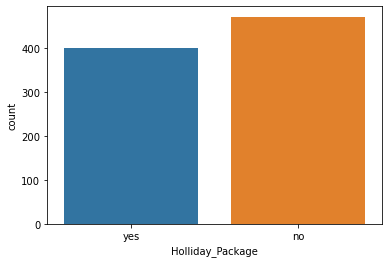

```python
sns.countplot(x='Holliday_Package',data=df,order=['yes','no'])
plt.show()
```

##### Inference:

46%(401 out of 872) of employees in organization opted for holliday packages and 54%(471 out of 872) are not opted for holliday packages.

### univariate Analysis:

#### Contineous Variables:

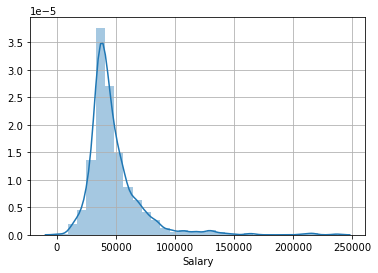

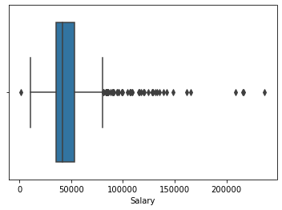

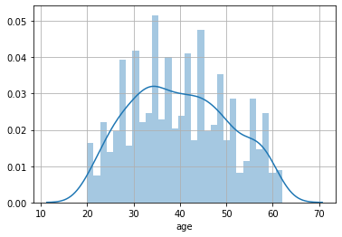

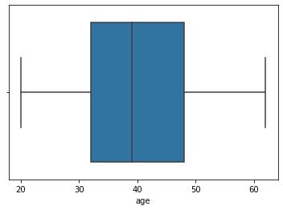

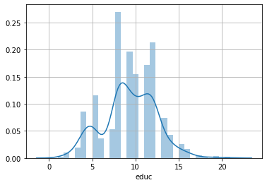

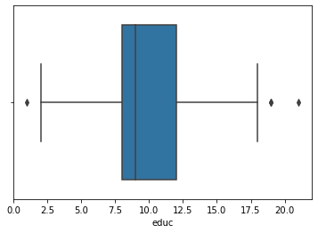

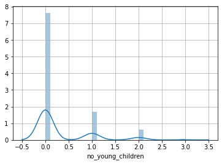

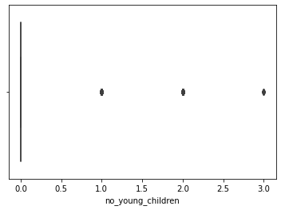

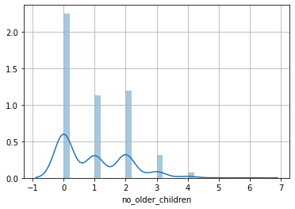

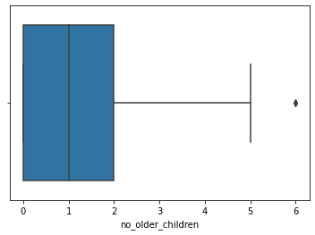

```python
cols=['Salary' ,'age', 'educ', 'no_young_children', 'no_older_children']
for i in cols:
    sns.distplot(df[i],hist=True,bins=30)
    plt.grid()
    plt.show()
    sns.boxplot(df[i])
    plt.show()
```

##### Inference:

salary has positively skewed and has more number of outliers in data.

Age is widely spread with min 20 nad max 62. There is no ouliers in data.

Most of the data in no of younger children lies between 0 to 2 and has outliers.

#### Skewness:

```python
df.skew()
```

```
Unnamed: 0           0.000000
Salary               3.103216
age                  0.146412
educ                -0.045501
no_young_children    1.946515
no_older_children    0.953951
dtype: float64
```

#### Categorical Variable:

```python
for feature in df.columns:
    if df[feature].dtype == 'object':
        print('feature:',feature)
        counts=df[feature].value_counts()
        print(counts)
        print('\n')
```

```
feature: Holliday_Package
no     471
yes    401
Name: Holliday_Package, dtype: int64


feature: foreign
no     656
yes    216
Name: foreign, dtype: int64
```

```
feature: Holliday_Package
```

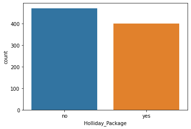

```
feature: foreign
```

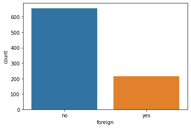

```python
for feature in df.columns:
    if df[feature].dtype == 'object':
        print('feature:',feature)
        sns.countplot(df[feature])
        plt.show()
        print('\n')
```

##### Inference:

46%(401 out of 872) of employees in organization opted for holliday packages and 54%(471 out of 872) are not opted for holliday packages.

### Bivariate Analysis:

#### Holliday_Package vs Salary:

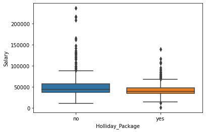

```python
sns.boxplot(x="Holliday_Package",y='Salary',data=df)
plt.show()
```

##### Inference:

Salary more than 150000 not opted for holiday packages.

Most of the employes less than 50000 salary is opted for holiday packages.

#### Holliday_Package vs Salary vs Age:

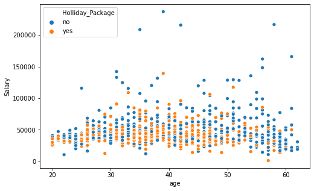

```python
plt.figure(figsize=(8,5))
sns.scatterplot(x="age", hue="Holliday_Package",y='Salary',data=df)
plt.show()
```

#### Holliday_Package vsSalary vs educ:

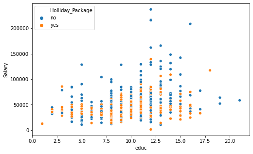

```python
plt.figure(figsize=(8,5))
sns.scatterplot(x="educ", hue="Holliday_Package",y='Salary',data=df)
plt.show()
```

#### Holliday_Package vs no_young_children vs Salary :

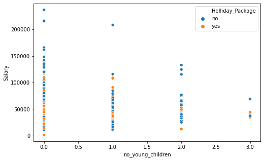

```python
plt.figure(figsize=(8,5))
sns.scatterplot(x="no_young_children", hue="Holliday_Package",y='Salary',data=df)
plt.show()
```

#### Holliday_Package vs no_older_children vs Salary:

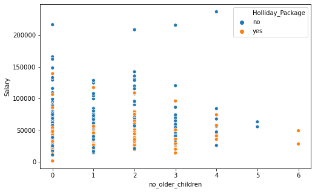

```python
plt.figure(figsize=(8,5))
sns.scatterplot(x="no_older_children", hue="Holliday_Package",y='Salary',data=df)
plt.show()
```

### Multivariate Analysis:

#### Pair Plot with Contineous Variable:

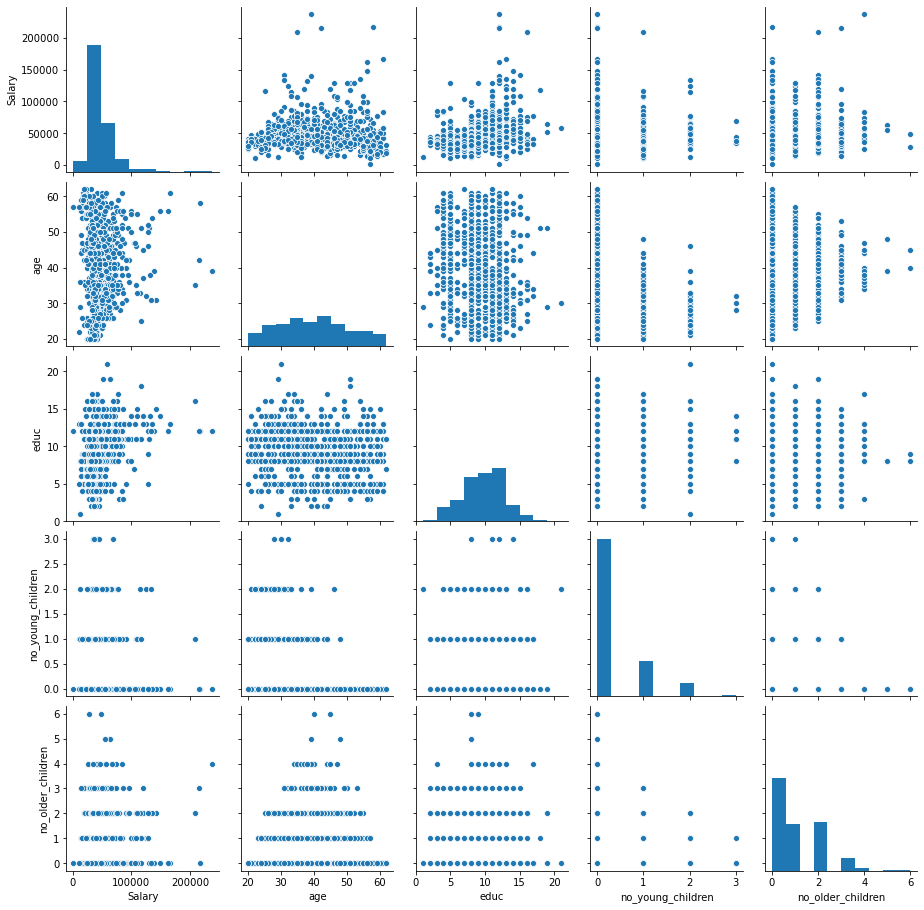

```python
sns.pairplot(df[['Salary' ,'age', 'educ', 'no_young_children', 'no_older_children']],diag_kind='hist')
plt.show()
```

#### Heatmap:

```python
corr = df.corr(method='pearson')
```

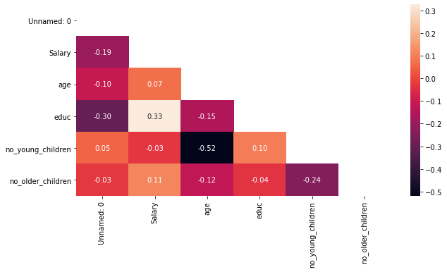

```python
mask = np.triu(np.ones_like(corr, dtype=np.bool))
fig = plt.subplots(figsize=(10, 5))
sns.heatmap(df.corr(), annot=True,fmt='.2f',mask=mask)
plt.show()
```

##### Inference:

There is no multicollinearity in data.

No of young children and age is negatively correlated which is high.

### Outlier Teatment:

#### Before Treatment:

```python
cont=df.dtypes[(df.dtypes!='uint8') & (df.dtypes!='object')].index
```

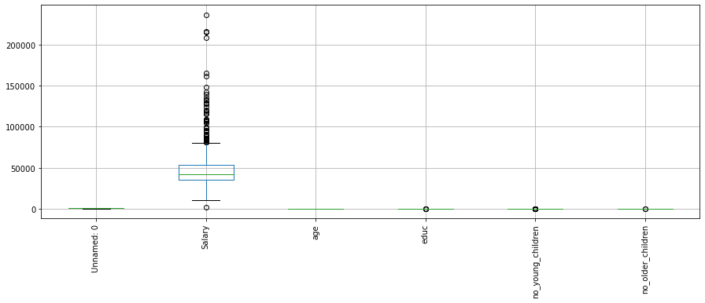

```python
df.boxplot(figsize=(15,5))
plt.xticks(rotation=90)
plt.show()
```

```python
def remove_outlier(col):
    sorted(col)
    Q1,Q3=np.percentile(col,[25,75])
    IQR=Q3-Q1
    lower_range= Q1-(1.5 * IQR)
    upper_range= Q3+(1.5 * IQR)
    return lower_range, upper_range
```

```python
for column in df[cont].columns:
    lr,ur=remove_outlier(df[column])
    df[column]=np.where(df[column]>ur,ur,df[column])
    df[column]=np.where(df[column]<lr,lr,df[column])
```

#### After Treatment:

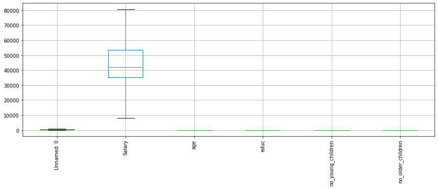

```python
df.boxplot(figsize=(15,5))
plt.xticks(rotation=90)
plt.show()
```

##### Inference:

Logestic Regression and LDA models are sensitive to Outliers.

Removal of outliers creates a normal distribution in some of my variables, and makes transformations for the other variables more effective. Therefore, it seems that removal of outliers before transformation is the better option.

Compare the respective medians of each box plot. If the median line of a box plot lies outside of the box of a comparison box plot, then there is likely to be a difference between the two groups.

```python
# drop the id column as it is useless for the model
df1 = df.drop(columns=['Unnamed: 0'], axis=1)
```

```python
df2 = df1.copy()
```

### 2.2 Do not scale the data. Encode the data (having string values) for Modelling. Data Split: Split the data into train and test (70:30). Apply Logistic Regression and LDA (linear discriminant analysis).

#### Creating get_dumies for categorical Variable:

```python
data = pd.get_dummies(df2, columns=['Holliday_Package','foreign'], drop_first = True)
```

```python
data.head()
```

|  | Salary | age | educ | no_young_children | no_older_children | Holliday_Package_yes | foreign_yes |
| --- | --- | --- | --- | --- | --- | --- | --- |
| 0 | 48412.0 | 30.0 | 8.0 | 0.0 | 1.0 | 0 | 0 |
| 1 | 37207.0 | 45.0 | 8.0 | 0.0 | 1.0 | 1 | 0 |
| 2 | 58022.0 | 46.0 | 9.0 | 0.0 | 0.0 | 0 | 0 |
| 3 | 66503.0 | 31.0 | 11.0 | 0.0 | 0.0 | 0 | 0 |
| 4 | 66734.0 | 44.0 | 12.0 | 0.0 | 2.0 | 0 | 0 |

#### Train & Test split:

```python
# Copy all the predictor variables into X dataframe
X = data.drop('Holliday_Package_yes', axis=1)

# Copy target into the y dataframe.
y = data['Holliday_Package_yes']
```

```python
# Split X and y into training and test set in 70:30 ratio
X_train, X_test, y_train, y_test = train_test_split(X, y, test_size=0.30 , random_state=1,stratify=y)
```

### Logistic Regression Model:

Linear regression is a basic and commonly used type of predictive analysis.

The overall idea of regression is to examine two things: (1) does a set of predictor variables do a good job in predicting an outcome (dependent) variable? (2) Which variables in particular are significant predictors of the outcome variable, and in what way do they–indicated by the magnitude and sign of the beta estimates–impact the outcome variable? These regression estimates are used to explain the relationship between one dependent variable and one or more independent variables.

The simplest form of the regression equation with one dependent and one independent variable is defined by the formula y = c + b*x, where y = estimated dependent variable score, c = constant, b = regression coefficient, and x = score on the independent variable.

```python
grid={'penalty':['l1','l2','none'],
      'solver':['lbfgs', 'liblinear'],
      'tol':[0.0001,0.000001]}
```

```python
model = LogisticRegression(max_iter=100000,n_jobs=2)
```

```python
grid_search = GridSearchCV(estimator = model, param_grid = grid, cv = 3,n_jobs=-1,scoring='f1')
```

```python
grid_search.fit(X_train, y_train)
```

```
GridSearchCV(cv=3, estimator=LogisticRegression(max_iter=100000, n_jobs=2),
             n_jobs=-1,
             param_grid={'penalty': ['l1', 'l2', 'none'],
                         'solver': ['lbfgs', 'liblinear'],
                         'tol': [0.0001, 1e-06]},
             scoring='f1')
```

```python
print(grid_search.best_params_,'\n')
print(grid_search.best_estimator_)
```

```
{'penalty': 'l2', 'solver': 'liblinear', 'tol': 1e-06}

LogisticRegression(max_iter=100000, n_jobs=2, solver='liblinear', tol=1e-06)
```

```python
best_model = grid_search.best_estimator_
```

```python
# Prediction on the training set

ytrain_predict = best_model.predict(X_train)
ytest_predict = best_model.predict(X_test)
```

```python
ytrain_predict
```

[output not shown]

```python
## Getting the probabilities on the test set

ytest_predict_prob=best_model.predict_proba(X_test)
pd.DataFrame(ytest_predict_prob).head()
```

|  | 0 | 1 |
| --- | --- | --- |
| 0 | 0.636523 | 0.363477 |
| 1 | 0.576651 | 0.423349 |
| 2 | 0.650835 | 0.349165 |
| 3 | 0.568064 | 0.431936 |
| 4 | 0.536356 | 0.463644 |

```
              precision    recall  f1-score   support

           0       0.63      0.79      0.70       329
           1       0.65      0.45      0.53       281

    accuracy                           0.63       610
   macro avg       0.64      0.62      0.62       610
weighted avg       0.64      0.63      0.62       610
```

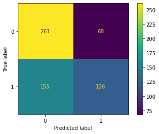

```python
## Confusion matrix on the training data

plot_confusion_matrix(best_model,X_train,y_train)
print(classification_report(y_train, ytrain_predict),'\n');
```

```
              precision    recall  f1-score   support

           0       0.64      0.83      0.72       142
           1       0.69      0.45      0.55       120

    accuracy                           0.66       262
   macro avg       0.67      0.64      0.63       262
weighted avg       0.66      0.66      0.64       262
```

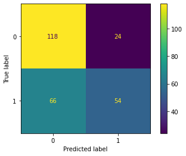

```python
## Confusion matrix on the test data

plot_confusion_matrix(best_model,X_test,y_test)
print(classification_report(y_test, ytest_predict),'\n');
```

```python
# Accuracy - Training Data

lr_train_acc = best_model.score(X_train, y_train)
lr_train_acc
```

```
0.6344262295081967
```

```python
lr_metrics=classification_report(y_train, ytrain_predict,output_dict=True)
df=pd.DataFrame(lr_metrics).transpose()
lr_train_f1=round(df.loc["1"][2],2)
lr_train_recall=round(df.loc["1"][1],2)
lr_train_precision=round(df.loc["1"][0],2)
print ('lr_train_precision ',lr_train_precision)
print ('lr_train_recall ',lr_train_recall)
print ('lr_train_f1 ',lr_train_f1)
```

```
lr_train_precision  0.65
lr_train_recall  0.45
lr_train_f1  0.53
```

```
AUC: 0.661
```

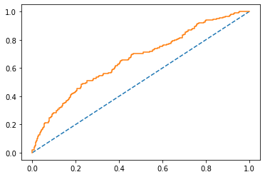

```python
### AUC and ROC for the training data
# predict probabilities
probs = best_model.predict_proba(X_train)
# keep probabilities for the positive outcome only
probs = probs[:, 1]
# calculate AUC
lr_train_auc = roc_auc_score(y_train, probs)
print('AUC: %.3f' % lr_train_auc)
# calculate roc curve
train_fpr, train_tpr, train_thresholds = roc_curve(y_train, probs)
plt.plot([0, 1], [0, 1], linestyle='--')
# plot the roc curve for the model
plt.plot(train_fpr, train_tpr);
```

```python
# Accuracy - Test Data

lr_test_acc = best_model.score(X_test, y_test)
lr_test_acc
```

```
0.6564885496183206
```

```
AUC: 0.675
```

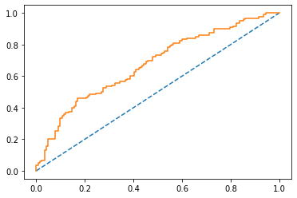

```python
# predict probabilities
probs = best_model.predict_proba(X_test)
# keep probabilities for the positive outcome only
probs = probs[:, 1]
# calculate AUC
lr_test_auc = roc_auc_score(y_test, probs)
print('AUC: %.3f' % lr_test_auc)
# calculate roc curve
test_fpr, test_tpr, test_thresholds = roc_curve(y_test, probs)
plt.plot([0, 1], [0, 1], linestyle='--')
# plot the roc curve for the model
plt.plot(test_fpr, test_tpr);
```

```python
lr_metrics=classification_report(y_test, ytest_predict,output_dict=True)
df=pd.DataFrame(lr_metrics).transpose()
lr_test_f1=round(df.loc["1"][2],2)
lr_test_recall=round(df.loc["1"][1],2)
lr_test_precision=round(df.loc["1"][0],2)
print ('lr_test_precision ',lr_test_precision)
print ('lr_test_recall ',lr_test_recall)
print ('lr_test_f1 ',lr_test_f1)
```

```
lr_test_precision  0.69
lr_test_recall  0.45
lr_test_f1  0.55
```